# Test Allianz Data Scientist Junior

Yuanxi Liu

2018/6/14

## 1. PREPARATION

#### Set working directory

```r
Sys.setlocale("LC_ALL", 'fr_Fr')
```

```
## [1] "fr_Fr/fr_Fr/fr_Fr/C/fr_Fr/C"
```

```r
setwd("~/Desktop/allianz/data")
```

## 2. IMPORT DES DONNEES

#### 2.1 caracteristiques 2005-2016

###### Lire tous les ’caracteristiques*.csv’ files

```r
list_file_caracteristiques<-list.files(pattern=glob2rx("caracteristiques*.csv"))
list_file_caracteristiques
```

```
##  [1] "caracteristiques_2005.csv" "caracteristiques_2006.csv"
##  [3] "caracteristiques_2007.csv" "caracteristiques_2008.csv"
##  [5] "caracteristiques_2009.csv" "caracteristiques_2010.csv"
##  [7] "caracteristiques_2011.csv" "caracteristiques_2012.csv"
##  [9] "caracteristiques_2013.csv" "caracteristiques_2014.csv"
## [11] "caracteristiques_2015.csv" "caracteristiques_2016.csv"
```

```r
first_ten_lines <- read.csv(list_file_caracteristiques[10], nrows = 10)
```

###### Lire les 10 premiers lignes des données de l’annee 2014

###### On trouve qu’un bug de ‘Num_Acc’, car gd nombre (integer).

###### Les accents français ne sont pas bien affichés.

###### Maximum integer pour R: Machine$integer.max = 2147483647

###### Num_Acc, ex ‘201400000001’ > max

###### Il est suffit de définir la classe de ‘Num_Acc’(id) comme un caractère au lieu d’integer.

###### On observe que tous les accents ne sont pas correctement affichés.

```r
library(DT)
colnames(first_ten_lines) = paste('<span style="color:red">', colnames(first_ten_lines), '</span>', sep = "")
datatable(first_ten_lines, escape = FALSE)
```

|  | Num_Acc | an | mois | jour | hrmn | lum | agg | int | atm | col | com | adr | gps | lat | long | dep |
| --- | --- | --- | --- | --- | --- | --- | --- | --- | --- | --- | --- | --- | --- | --- | --- | --- |
| 1 | 201400000001 | 14 | 5 | 7 | 2015 | 1 | 2 | 1 | 1 | 3 | 11 | route de don | M | 0 | 0 | 590 |
| 2 | 201400000002 | 14 | 5 | 31 | 430 | 1 | 2 | 1 | 1 | 6 | 11 | 106 ROUTE DE DON | M | 0 | 0 | 590 |
| 3 | 201400000003 | 14 | 8 | 23 | 1800 | 1 | 2 | 9 | 1 | 3 | 52 | 75 bis rue jean jaures | M | 0 | 0 | 590 |
| 4 | 201400000004 | 14 | 6 | 12 | 1700 | 1 | 2 | 1 | 1 | 1 | 25 | rue des Sablonnieres D41 | M | 0 | 0 | 590 |
| 5 | 201400000005 | 14 | 6 | 23 | 500 | 2 | 1 | 1 | 1 | 1 | 25 |  | M | 0 | 0 | 590 |
| 6 | 201400000006 | 14 | 10 | 11 | 630 | 5 | 1 | 6 | 2 | 2 | 550 |  | M | 0 | 0 | 590 |
| 7 | 201400000007 | 14 | 10 | 11 | 1445 | 1 | 2 | 9 | 1 | 7 | 281 | Chemin des Loups | M | 0 | 0 | 590 |
| 8 | 201400000008 | 14 | 10 | 16 | 1200 | 1 | 2 | 4 | 1 | 6 | 51 | Rue gabriel Pri | M | 5053223 | 281490 | 590 |
| 9 | 201400000009 | 14 | 11 | 2 | 1100 | 1 | 1 | 1 | 1 | 1 | 257 |  | M | 0 | 0 | 590 |
| 10 | 201400000010 | 14 | 11 | 30 | 1930 | 5 | 2 | 1 | 8 | 6 | 524 | RUE DE VERDUN | M | 0 | 0 | 590 |

###### Le codage européen est ISO_8859-1.

```r
codepages <- iconvlist()
```

```r
first_ten_lines_caracteristiques <- read.csv(list_file_caracteristiques[10], nrows = 10, fileEncoding = 'ISO_8859-1')
first_ten_lines_caracteristiques
```

```
##      Num_Acc an mois jour hrmn lum agg int atm col com
## 1  2.014e+11 14    5    7 2015   1   2   1   1   3  11
## 2  2.014e+11 14    5   31  430   1   2   1   1   6  11
## 3  2.014e+11 14    8   23 1800   1   2   9   1   3  52
## 4  2.014e+11 14    6   12 1700   1   2   1   1   1  25
## 5  2.014e+11 14    6   23  500   2   1   1   1   1  25
## 6  2.014e+11 14   10   11  630   5   1   6   2   2 550
## 7  2.014e+11 14   10   11 1445   1   2   9   1   7 281
## 8  2.014e+11 14   10   16 1200   1   2   4   1   6  51
## 9  2.014e+11 14   11    2 1100   1   1   1   1   1 257
## 10 2.014e+11 14   11   30 1930   5   2   1   8   6 524
##                         adr gps     lat   long dep
## 1              route de don   M       0      0 590
## 2          106 ROUTE DE DON   M       0      0 590
## 3    75 bis rue jean jaures   M       0      0 590
## 4  rue des Sablonnieres D41   M       0      0 590
## 5                             M       0      0 590
## 6                             M       0      0 590
## 7          Chemin des Loups   M       0      0 590
## 8          Rue gabriel Péri   M 5053223 281490 590
## 9                             M       0      0 590
## 10            RUE DE VERDUN   M       0      0 590
```

```r
colnames(first_ten_lines_caracteristiques) = paste('<span style="color:red">', colnames(first_ten_lines_caracteristiques), '</span>', sep = "")
datatable(first_ten_lines_caracteristiques, escape = FALSE)
```

|  | Num_Acc | an | mois | jour | hrmn | lum | agg | int | atm | col | com | adr | gps | lat | long | dep |
| --- | --- | --- | --- | --- | --- | --- | --- | --- | --- | --- | --- | --- | --- | --- | --- | --- |
| 1 | 201400000001 | 14 | 5 | 7 | 2015 | 1 | 2 | 1 | 1 | 3 | 11 | route de don | M | 0 | 0 | 590 |
| 2 | 201400000002 | 14 | 5 | 31 | 430 | 1 | 2 | 1 | 1 | 6 | 11 | 106 ROUTE DE DON | M | 0 | 0 | 590 |
| 3 | 201400000003 | 14 | 8 | 23 | 1800 | 1 | 2 | 9 | 1 | 3 | 52 | 75 bis rue jean jaures | M | 0 | 0 | 590 |
| 4 | 201400000004 | 14 | 6 | 12 | 1700 | 1 | 2 | 1 | 1 | 1 | 25 | rue des Sablonnieres D41 | M | 0 | 0 | 590 |
| 5 | 201400000005 | 14 | 6 | 23 | 500 | 2 | 1 | 1 | 1 | 1 | 25 |  | M | 0 | 0 | 590 |
| 6 | 201400000006 | 14 | 10 | 11 | 630 | 5 | 1 | 6 | 2 | 2 | 550 |  | M | 0 | 0 | 590 |
| 7 | 201400000007 | 14 | 10 | 11 | 1445 | 1 | 2 | 9 | 1 | 7 | 281 | Chemin des Loups | M | 0 | 0 | 590 |
| 8 | 201400000008 | 14 | 10 | 16 | 1200 | 1 | 2 | 4 | 1 | 6 | 51 | Rue gabriel Péri | M | 5053223 | 281490 | 590 |
| 9 | 201400000009 | 14 | 11 | 2 | 1100 | 1 | 1 | 1 | 1 | 1 | 257 |  | M | 0 | 0 | 590 |
| 10 | 201400000010 | 14 | 11 | 30 | 1930 | 5 | 2 | 1 | 8 | 6 | 524 | RUE DE VERDUN | M | 0 | 0 | 590 |

###### L’adresse est correctement affichée.

###### Selon la Description_des_bases_de_donnees_ONISR_-Annees_2005_a_2016,

###### Définir la classe de chaque variable (integer, caractere ou facteur).

###### Ouvrir la liste de ’caracteristiques*.csv’, ###### Le séparateur de ‘2009’ est tab, les autres sont comma. ###### Test caracteristiques*.csv, on trouve les erreurs.

###### caracteristiques_2005-2008

##### caracteristiques_2005-2008

```r
data_caracteristiques_part1 <- do.call(rbind, lapply(list_file_caracteristiques[c(1,2,3,4)], function(x) cbind(read.csv(x, colClasses = c(Num_Acc="character", lum="factor", dep="factor", com="factor", agg="factor", int="factor", atm="factor", col="factor", adr="character", gps="factor", lat="integer", long="integer"), fileEncoding = "ISO_8859-1", na.strings=c("NA","NaN", "", "0")))))
```

##### caracteristiques_2009

```r
# Erreur: '-' n'est pas un integer.
```

##### caracteristiques_2010-2016

```r
# Erreur: '61285E7' n'est pas un integer pour longitude.
```

##### Solution:

##### On considère long comme caractère, transformer long ‘as.integer’, obtenir NA pour cette observation.

##### Boucle d’import

```r
data_caracteristiques_part1 <- do.call(rbind, lapply(list_file_caracteristiques[c(1,2,3,4)], function(x) cbind(read.csv(x, colClasses = c(Num_Acc="character", lum="factor", dep="factor", com="factor", agg="factor", int="factor", atm="factor", col="factor", adr="character", gps="factor", lat="integer", long="character"), fileEncoding = "ISO_8859-1", na.strings=c("NA","NaN", "", "0")))))
data_caracteristiques_part2 <- read.csv(list_file_caracteristiques[5], colClasses = c(Num_Acc="character", lum="factor", dep="factor", com="factor", agg="factor", int="factor", atm="factor", col="factor", adr="character", gps="factor", lat="integer", long="character"), fileEncoding = "ISO_8859-1", sep = "\t", na.strings=c("NA","NaN", "", "0")) # Windows-1252
data_caracteristiques_part3 <- do.call(rbind, lapply(list_file_caracteristiques[c(6,7,8,9,10,11,12)], function(x) cbind(read.csv(x, colClasses = c(Num_Acc="character", lum="factor", dep="factor", com="factor", agg="factor", int="factor", atm="factor", col="factor", adr="character", gps="factor", lat="integer", long="character"), fileEncoding = "ISO_8859-1", na.strings=c("NA","NaN", "", "0")))))
data_caracteristiques <- rbind(data_caracteristiques_part1,data_caracteristiques_part2,data_caracteristiques_part3)
data_caracteristiques$long <- as.integer(data_caracteristiques$long)
colnames(data_caracteristiques) = paste('<span style="color:red">', colnames(data_caracteristiques), '</span>', sep = "")
datatable(head(data_caracteristiques, 50), escape = FALSE)
```

|  | Num_Acc | an | mois | jour | hrmn | lum | agg | int | atm | col | com | adr | gps | lat | long | dep |
| --- | --- | --- | --- | --- | --- | --- | --- | --- | --- | --- | --- | --- | --- | --- | --- | --- |
| 1 | 200500000001 | 5 | 1 | 12 | 1900 | 3 | 2 | 1 | 1 | 3 | 011 | CD41B | M | 5051500 | 294400 | 590 |
| 2 | 200500000002 | 5 | 1 | 21 | 1600 | 1 | 2 | 1 | 1 | 1 | 051 | rue de Lille | M | 5053700 | 280200 | 590 |
| 3 | 200500000003 | 5 | 1 | 21 | 1845 | 3 | 1 | 1 | 2 | 1 | 051 |  | M | 5054600 | 280000 | 590 |
| 4 | 200500000004 | 5 | 1 | 4 | 1615 | 1 | 1 | 1 | 1 | 5 | 082 |  | M | 5098700 | 240800 | 590 |
| 5 | 200500000005 | 5 | 1 | 10 | 1945 | 3 | 1 | 1 | 3 | 6 | 478 |  | M | 5096400 | 247500 | 590 |
| 6 | 200500000006 | 5 | 1 | 28 | 1415 | 1 | 1 | 1 | 8 | 6 | 082 |  | M | 5099500 | 239700 | 590 |
| 7 | 200500000007 | 5 | 1 | 3 | 1530 | 1 | 1 | 1 | 1 | 3 | 130 |  | M | 0 | 0 | 590 |
| 8 | 200500000008 | 5 | 1 | 18 | 2115 | 5 | 2 | 1 | 2 | 6 | 404 | le hameau du lac | M | 5105200 | 253300 | 590 |
| 9 | 200500000009 | 5 | 1 | 25 | 1715 | 1 | 1 | 2 | 8 | 3 | 309 |  | M | 5097300 | 257100 | 590 |
| 10 | 200500000010 | 5 | 1 | 29 | 2015 | 3 | 1 | 1 | 2 | 6 | 260 |  | M | 5106500 | 252400 | 590 |

[output cut: 40 more lines]

#### 2.2 Lieux 2005-2016

###### De même façon pour la suite:

###### Lire tous les lieux*.csv fichiers

```r
list_file_lieux<-list.files(pattern=glob2rx("lieux*.csv"))
list_file_lieux
```

```
##  [1] "lieux_2005.csv" "lieux_2006.csv" "lieux_2007.csv" "lieux_2008.csv"
##  [5] "lieux_2009.csv" "lieux_2010.csv" "lieux_2011.csv" "lieux_2012.csv"
##  [9] "lieux_2013.csv" "lieux_2014.csv" "lieux_2015.csv" "lieux_2016.csv"
```

###### Les 10 premiers lignes:

```r
first_ten_lines_lieux <- read.csv(list_file_lieux[10], nrows = 10)
colnames(first_ten_lines_lieux) = paste('<span style="color:red">', colnames(first_ten_lines_lieux), '</span>', sep = "")
datatable(first_ten_lines_lieux, escape = FALSE)
```

|  | Num_Acc | catr | voie | v1 | v2 | circ | nbv | pr | pr1 | vosp | prof | plan | lartpc | larrout | surf | infra | situ | env1 |
| --- | --- | --- | --- | --- | --- | --- | --- | --- | --- | --- | --- | --- | --- | --- | --- | --- | --- | --- |
| 1 | 201400000001 | 3 | 41 |  |  | 2 | 0 | 0 | 0 | 0 | 1 | 1 | 0 | 60 | 1 | 0 | 1 | 0 |
| 2 | 201400000002 | 3 | 41 |  |  | 2 | 2 | 0 | 0 | 0 | 1 | 2 | 0 | 62 | 1 | 0 | 4 | 99 |
| 3 | 201400000003 | 3 | 39 |  |  | 2 | 0 | 0 | 0 | 0 | 1 | 1 | 0 | 60 | 1 | 0 | 1 | 99 |
| 4 | 201400000004 | 3 | 41 |  |  | 2 | 2 | 0 | 800 | 0 | 0 | 1 | 0 | 60 | 1 | 0 | 1 | 99 |
| 5 | 201400000005 | 3 | 141 |  |  | 2 | 0 | 0 | 0 | 0 | 0 | 2 | 0 | 0 | 2 | 0 | 0 | 0 |
| 6 | 201400000006 | 2 | 47 |  |  | 3 | 2 | 0 | 0 | 0 | 0 | 1 | 0 | 0 | 2 | 0 | 1 | 99 |
| 7 | 201400000007 | 4 | 0 |  |  | 2 | 1 | 0 | 0 | 0 | 0 | 2 | 0 | 0 | 6 | 0 | 1 | 99 |
| 8 | 201400000008 | 3 | 145 |  |  | 2 | 2 | 0 | 281 | 0 | 1 | 3 | 0 | 0 | 1 | 5 | 1 | 99 |
| 9 | 201400000009 | 3 | 141 |  |  | 2 | 2 | 0 | 0 | 0 | 1 | 1 | 0 | 0 | 1 | 0 | 1 | 0 |
| 10 | 201400000010 | 4 | 0 |  |  | 2 | 2 | 0 | 0 | 0 | 1 | 4 | 0 | 0 | 2 | 0 | 3 | 99 |

###### Facteur = 0, => valeur manquante (NA).

###### Boucle d’import

```r
data_lieux <- do.call(rbind, lapply(list_file_lieux, function(x) cbind(read.csv(x, colClasses = c(Num_Acc="character", catr="factor", voie="character", v1="integer", v2="factor", circ="factor", nbv="integer", vosp="factor", prof="factor", plan="factor", surf="factor", infra="factor", situ="factor"), fileEncoding = "ISO_8859-1", na.strings=c("NA","NaN", "", "0", 0)))))
```

```r
colnames(data_lieux) = paste('<span style="color:red">', colnames(data_lieux), '</span>', sep = "")
datatable(head(data_lieux, 50), escape = FALSE)
```

|  | Num_Acc | catr | voie | v1 | v2 | circ | nbv | pr | pr1 | vosp | prof | plan | lartpc | larrout | surf | infra | situ | env1 |
| --- | --- | --- | --- | --- | --- | --- | --- | --- | --- | --- | --- | --- | --- | --- | --- | --- | --- | --- |
| 1 | 200500000001 | 3 | 00041 |  | B | 2 | 2 | 1 | 430 |  | 1 | 1 | 0 | 63 | 1 |  | 1 | 0 |
| 2 | 200500000002 | 2 | 00041 |  |  |  | 2 |  |  | 1 | 1 | 1 | 0 | 100 | 1 |  | 5 | 0 |
| 3 | 200500000003 | 2 | 00041 |  |  |  | 0 |  |  | 1 | 1 | 1 | 0 | 0 | 2 |  | 5 | 0 |
| 4 | 200500000004 | 3 | 00916 |  |  | 2 | 2 |  |  |  | 1 | 1 | 0 | 0 | 1 |  | 1 | 0 |
| 5 | 200500000005 | 3 | 00110 |  |  | 2 | 2 | 24 | 630 |  | 1 | 3 | 0 | 59 | 2 |  | 3 | 0 |
| 6 | 200500000006 | 3 | 00916 |  |  | 2 | 2 | 47 |  |  | 1 | 3 | 0 | 70 | 2 |  | 5 | 0 |
| 7 | 200500000007 | 3 | 00600 |  |  | 2 | 0 | 6 | 638 |  | 1 | 1 | 0 | 78 | 1 |  | 1 | 0 |
| 8 | 200500000008 | 3 | 00947 |  |  | 2 | 2 | 53 | 900 |  | 1 | 3 | 0 | 69 | 1 |  | 3 | 0 |
| 9 | 200500000009 | 3 | 00055 |  |  | 2 | 2 | 3 | 200 |  |  | 1 | 0 | 67 | 1 |  | 1 | 0 |
| 10 | 200500000010 | 2 | 00001 |  |  |  | 2 | 32 | 13 |  | 1 | 1 | 0 | 70 | 2 |  | 1 | 0 |

[output cut: 40 more lines]

#### 2.3 Vehicules 2005-2016

###### Lire tous les vehicules*.csv fichiers

```r
list_file_vehicules<-list.files(pattern=glob2rx("vehicules*.csv"))
list_file_vehicules
```

```
##  [1] "vehicules_2005.csv" "vehicules_2006.csv" "vehicules_2007.csv"
##  [4] "vehicules_2008.csv" "vehicules_2009.csv" "vehicules_2010.csv"
##  [7] "vehicules_2011.csv" "vehicules_2012.csv" "vehicules_2013.csv"
## [10] "vehicules_2014.csv" "vehicules_2015.csv" "vehicules_2016.csv"
```

###### Les 10 premiers lignes:

```r
first_10_lines_vehicules <- read.csv(list_file_vehicules[10], nrows = 10)
first_10_lines_vehicules
```

```
##      Num_Acc senc catv occutc obs obsm choc manv num_veh
## 1  2.014e+11    0   33      0   0    2    1    1     A01
## 2  2.014e+11    0    7      0   0    0    6   15     B02
## 3  2.014e+11    0    7      0   1    0    7   13     A01
## 4  2.014e+11    0    2      0   0    2    1    1     A01
## 5  2.014e+11    0    7      0   0    2    7   15     B02
## 6  2.014e+11    0    7      0   0    2    1   13     A01
## 7  2.014e+11    0   38      0   0    2    1    0     B02
## 8  2.014e+11    0    7      0   0    2    2   13     B02
## 9  2.014e+11    0    7      0   0    2    2    1     A01
## 10 2.014e+11    0   17      0   0    0    5    1     B02
```

```r
colnames(first_10_lines_vehicules) = paste('<span style="color:red">', colnames(first_10_lines_vehicules), '</span>', sep = "")
datatable(first_10_lines_vehicules, escape = FALSE)
```

|  | Num_Acc | senc | catv | occutc | obs | obsm | choc | manv | num_veh |
| --- | --- | --- | --- | --- | --- | --- | --- | --- | --- |
| 1 | 201400000001 | 0 | 33 | 0 | 0 | 2 | 1 | 1 | A01 |
| 2 | 201400000001 | 0 | 7 | 0 | 0 | 0 | 6 | 15 | B02 |
| 3 | 201400000002 | 0 | 7 | 0 | 1 | 0 | 7 | 13 | A01 |
| 4 | 201400000003 | 0 | 2 | 0 | 0 | 2 | 1 | 1 | A01 |
| 5 | 201400000003 | 0 | 7 | 0 | 0 | 2 | 7 | 15 | B02 |
| 6 | 201400000004 | 0 | 7 | 0 | 0 | 2 | 1 | 13 | A01 |
| 7 | 201400000004 | 0 | 38 | 0 | 0 | 2 | 1 | 0 | B02 |
| 8 | 201400000005 | 0 | 7 | 0 | 0 | 2 | 2 | 13 | B02 |
| 9 | 201400000005 | 0 | 7 | 0 | 0 | 2 | 2 | 1 | A01 |
| 10 | 201400000006 | 0 | 17 | 0 | 0 | 0 | 5 | 1 | B02 |

###### Boucle d’import

```r
data_vehicules <- do.call(rbind, lapply(list_file_vehicules, function(x) cbind(read.csv(x, colClasses = c(Num_Acc="character", senc="factor", catv="factor", obs="factor", obsm="factor", choc="factor", manv="factor"), fileEncoding = "ISO_8859-1", na.strings=c("NA","NaN", "")))))
```

```r
colnames(data_vehicules) = paste('<span style="color:red">', colnames(data_vehicules), '</span>', sep = "")
datatable(head(data_vehicules, 50), escape = FALSE)
```

|  | Num_Acc | senc | catv | occutc | obs | obsm | choc | manv | num_veh |
| --- | --- | --- | --- | --- | --- | --- | --- | --- | --- |
| 1 | 200500000001 | 0 | 07 | 0 | 00 | 2 | 1 | 01 | A01 |
| 2 | 200500000001 | 0 | 07 | 0 | 00 | 2 | 8 | 10 | B02 |
| 3 | 200500000002 | 0 | 07 | 0 | 00 | 2 | 7 | 16 | A01 |
| 4 | 200500000002 | 0 | 02 | 0 | 00 | 2 | 1 | 01 | B02 |
| 5 | 200500000003 | 0 | 02 | 0 | 00 | 2 | 1 | 01 | A01 |
| 6 | 200500000003 | 0 | 02 | 0 | 00 | 2 | 1 | 01 | B02 |
| 7 | 200500000004 | 0 | 07 | 0 | 00 | 2 | 1 | 13 | A01 |
| 8 | 200500000004 | 0 | 07 | 0 | 00 | 2 | 0 | 01 | B02 |
| 9 | 200500000004 | 0 | 07 | 0 | 00 | 2 | 8 | 01 | C03 |
| 10 | 200500000005 | 0 | 07 | 0 | 06 | 0 | 8 | 01 | A01 |

[output cut: 40 more lines]

#### 2.4 Usagers 2005-2016

###### Lire tous les usagers*.csv fichiers

```r
list_file_usagers<-list.files(pattern=glob2rx("usagers*.csv"))
list_file_usagers
```

```
##  [1] "usagers_2005.csv" "usagers_2006.csv" "usagers_2007.csv"
##  [4] "usagers_2008.csv" "usagers_2009.csv" "usagers_2010.csv"
##  [7] "usagers_2011.csv" "usagers_2012.csv" "usagers_2013.csv"
## [10] "usagers_2014.csv" "usagers_2015.csv" "usagers_2016.csv"
```

###### Les 10 premiers lignes:

```r
first_10_lines_usagers <- read.csv(list_file_usagers[10], nrows = 10)
first_10_lines_usagers
```

```
##      Num_Acc place catu grav sexe trajet secu locp actp etatp an_nais
## 1  2.014e+11     1    1    3    1      5   21    0    0     0    1971
## 2  2.014e+11     1    1    1    1      5   11    0    0     0    1992
## 3  2.014e+11     1    1    4    1      5   11    0    0     0    1983
## 4  2.014e+11     2    2    3    1      0   11    0    0     0    1990
## 5  2.014e+11     1    1    3    1      5   21    0    0     0    1974
## 6  2.014e+11     1    1    1    2      5   11    0    0     0    1970
## 7  2.014e+11     1    1    3    1      0   11    0    0     0    1971
## 8  2.014e+11     1    1    1    1      4   11    0    0     0    1958
## 9  2.014e+11     1    1    1    1      0   11    0    0     0    1995
## 10 2.014e+11     1    1    4    1      1   11    0    0     0    1967
##    num_veh
## 1      A01
## 2      B02
## 3      A01
## 4      A01
## 5      A01
## 6      B02
## 7      A01
## 8      B02
## 9      B02
## 10     A01
```

```r
colnames(first_10_lines_usagers) = paste('<span style="color:red">', colnames(first_10_lines_usagers), '</span>', sep = "")
datatable(first_10_lines_usagers, escape = FALSE)
```

|  | Num_Acc | place | catu | grav | sexe | trajet | secu | locp | actp | etatp | an_nais | num_veh |
| --- | --- | --- | --- | --- | --- | --- | --- | --- | --- | --- | --- | --- |
| 1 | 201400000001 | 1 | 1 | 3 | 1 | 5 | 21 | 0 | 0 | 0 | 1971 | A01 |
| 2 | 201400000001 | 1 | 1 | 1 | 1 | 5 | 11 | 0 | 0 | 0 | 1992 | B02 |
| 3 | 201400000002 | 1 | 1 | 4 | 1 | 5 | 11 | 0 | 0 | 0 | 1983 | A01 |
| 4 | 201400000002 | 2 | 2 | 3 | 1 | 0 | 11 | 0 | 0 | 0 | 1990 | A01 |
| 5 | 201400000003 | 1 | 1 | 3 | 1 | 5 | 21 | 0 | 0 | 0 | 1974 | A01 |
| 6 | 201400000003 | 1 | 1 | 1 | 2 | 5 | 11 | 0 | 0 | 0 | 1970 | B02 |
| 7 | 201400000004 | 1 | 1 | 3 | 1 | 0 | 11 | 0 | 0 | 0 | 1971 | A01 |
| 8 | 201400000004 | 1 | 1 | 1 | 1 | 4 | 11 | 0 | 0 | 0 | 1958 | B02 |
| 9 | 201400000005 | 1 | 1 | 1 | 1 | 0 | 11 | 0 | 0 | 0 | 1995 | B02 |
| 10 | 201400000005 | 1 | 1 | 4 | 1 | 1 | 11 | 0 | 0 | 0 | 1967 | A01 |

###### Boucle d’import

```r
data_usagers <- do.call(rbind, lapply(list_file_usagers, function(x) cbind(read.csv(x, colClasses = c(Num_Acc="character", place="factor", catu="factor", grav="factor", sexe="factor", trajet="factor", secu="factor", locp="factor", actp="factor", etatp="factor", num_veh="factor"), fileEncoding = "ISO_8859-1", na.strings=c("NA","NaN", "")))))
```

```r
colnames(data_usagers) = paste('<span style="color:red">', colnames(data_usagers), '</span>', sep = "")
datatable(head(data_usagers, 50), escape = FALSE)
```

|  | Num_Acc | place | catu | grav | sexe | trajet | secu | locp | actp | etatp | an_nais | num_veh |
| --- | --- | --- | --- | --- | --- | --- | --- | --- | --- | --- | --- | --- |
| 1 | 200500000001 | 1 | 1 | 4 | 1 | 1 | 11 | 0 | 0 | 0 | 1976 | A01 |
| 2 | 200500000001 | 1 | 1 | 3 | 2 | 3 | 11 | 0 | 0 | 0 | 1968 | B02 |
| 3 | 200500000001 | 2 | 2 | 1 | 1 | 0 | 11 | 0 | 0 | 0 | 1964 | B02 |
| 4 | 200500000001 | 4 | 2 | 1 | 1 | 0 | 31 | 0 | 0 | 0 | 2004 | B02 |
| 5 | 200500000001 | 5 | 2 | 1 | 1 | 0 | 11 | 0 | 0 | 0 | 1998 | B02 |
| 6 | 200500000001 | 3 | 2 | 1 | 2 | 0 | 11 | 0 | 0 | 0 | 1991 | B02 |
| 7 | 200500000002 | 1 | 1 | 1 | 1 | 5 | 11 | 0 | 0 | 0 | 1955 | A01 |
| 8 | 200500000002 | 1 | 1 | 3 | 1 | 5 | 21 | 0 | 0 | 0 | 1979 | B02 |
| 9 | 200500000003 | 1 | 1 | 1 | 1 | 1 | 21 | 0 | 0 | 0 | 1983 | A01 |
| 10 | 200500000003 | 1 | 1 | 3 | 1 | 1 | 21 | 0 | 0 | 0 | 1956 | B02 |

[output cut: 40 more lines]

```r
# ??? Num_veh ??? identifiant duplicate??? => facteur
```

## 3. EXPLORATION DES DONNEES

##### Pour la suite on utilisera uniquement la dernière année 2016

```r
data_caracteristiques_2016 <- read.csv(list_file_caracteristiques[12], colClasses = c(Num_Acc="character", lum="factor", dep="factor", com="factor", agg="factor", int="factor", atm="factor", col="factor", adr="character", gps="factor", lat="integer", long="integer"), fileEncoding = "ISO_8859-1", na.strings=c("NA","NaN", "", "0"))

colnames(data_caracteristiques_2016) = paste('<span style="color:red">', colnames(data_caracteristiques_2016), '</span>', sep = "")
datatable(head(data_caracteristiques_2016, 50), escape = FALSE)
```

|  | Num_Acc | an | mois | jour | hrmn | lum | agg | int | atm | col | com | adr | gps | lat | long | dep |
| --- | --- | --- | --- | --- | --- | --- | --- | --- | --- | --- | --- | --- | --- | --- | --- | --- |
| 1 | 201600000001 | 16 | 2 | 1 | 1445 | 1 | 2 | 1 | 8 | 3 | 005 | 46, rue Sonneville | M | 0 | 0 | 590 |
| 2 | 201600000002 | 16 | 3 | 16 | 1800 | 1 | 2 | 6 | 1 | 6 | 005 | 1a rue du cimetière | M | 0 | 0 | 590 |
| 3 | 201600000003 | 16 | 7 | 13 | 1900 | 1 | 1 | 1 | 1 | 6 | 011 |  | M | 0 | 0 | 590 |
| 4 | 201600000004 | 16 | 8 | 15 | 1930 | 2 | 2 | 1 | 7 | 3 | 477 | 52 rue victor hugo | M | 0 | 0 | 590 |
| 5 | 201600000005 | 16 | 12 | 23 | 1100 | 1 | 2 | 3 | 1 | 3 | 011 | rue Joliot curie | M | 0 | 0 | 590 |
| 6 | 201600000006 | 16 | 12 | 23 | 1115 | 1 | 2 | 1 | 7 | 6 | 011 | Rue Jean-baptiste LEBAS | M | 0 | 0 | 590 |
| 7 | 201600000007 | 16 | 5 | 1 | 1145 | 1 | 2 | 1 | 7 | 2 | 051 | rue Jules FERRY | M | 0 | 0 | 590 |
| 8 | 201600000008 | 16 | 5 | 14 | 1915 | 2 | 1 | 1 | 1 | 1 | 250 |  | M | 0 | 0 | 590 |
| 9 | 201600000009 | 16 | 9 | 23 | 1900 | 1 | 2 | 1 | 1 | 3 | 051 | rn41 | M | 0 | 0 | 590 |
| 10 | 201600000010 | 16 | 12 | 30 | 1030 | 1 | 1 | 1 | 9 | 6 | 303 |  | M | 0 | 0 | 590 |

[output cut: 40 more lines]

```r
data_lieux_2016 <- read.csv(list_file_lieux[12], colClasses = c(Num_Acc="character", catr="factor", voie="character", v1="integer", v2="factor", circ="factor", nbv="integer", vosp="factor", prof="factor", plan="factor", surf="factor", infra="factor", situ="factor"), fileEncoding = "ISO_8859-1", na.strings=c("NA","NaN", "", "0", 0))

colnames(data_lieux_2016) = paste('<span style="color:red">', colnames(data_lieux_2016), '</span>', sep = "")
datatable(head(data_lieux_2016, 50), escape = FALSE)
```

|  | Num_Acc | catr | voie | v1 | v2 | circ | nbv | pr | pr1 | vosp | prof | plan | lartpc | larrout | surf | infra | situ | env1 |
| --- | --- | --- | --- | --- | --- | --- | --- | --- | --- | --- | --- | --- | --- | --- | --- | --- | --- | --- |
| 1 | 201600000001 | 3 | 39 |  |  | 2 | 0 |  |  |  | 1 | 3 | 0 | 0 | 1 |  | 1 | 0 |
| 2 | 201600000002 | 3 | 39 |  |  | 1 | 0 |  |  |  | 1 | 2 | 0 | 58 | 1 |  | 1 | 0 |
| 3 | 201600000003 | 3 | 1 |  |  | 2 | 2 |  |  |  | 1 | 3 | 0 | 68 | 2 |  | 3 | 99 |
| 4 | 201600000004 | 4 |  |  |  | 2 | 0 |  |  |  | 1 | 1 | 0 | 0 | 1 |  | 1 | 99 |
| 5 | 201600000005 | 4 |  |  |  |  | 0 |  |  |  |  | 1 | 0 | 0 | 1 |  | 1 | 3 |
| 6 | 201600000006 | 3 | 41 |  |  | 2 | 0 |  |  |  | 1 | 1 | 0 | 0 | 1 |  | 1 | 99 |
| 7 | 201600000007 | 3 | 1 |  |  | 2 | 0 |  |  |  | 1 | 1 | 70 | 0 | 1 |  | 1 | 99 |
| 8 | 201600000008 | 3 | 2 |  | D | 2 | 2 |  |  |  | 1 | 1 | 0 | 70 | 1 |  | 1 | 0 |
| 9 | 201600000009 | 4 |  |  |  | 2 | 2 |  |  |  | 1 |  | 0 | 0 | 1 |  | 1 | 99 |
| 10 | 201600000010 | 4 |  |  | A | 2 | 0 |  |  |  |  | 1 | 0 | 44 | 7 |  | 1 | 0 |

[output cut: 40 more lines]

```r
data_vehicules_2016 <- read.csv(list_file_vehicules[12], colClasses = c(Num_Acc="character", senc="factor", catv="factor", obs="factor", obsm="factor", choc="factor", manv="factor"), fileEncoding = "ISO_8859-1", na.strings=c("NA","NaN", ""))

colnames(data_vehicules_2016) = paste('<span style="color:red">', colnames(data_vehicules_2016), '</span>', sep = "")
datatable(head(data_vehicules_2016, 50), escape = FALSE)
```

|  | Num_Acc | senc | catv | occutc | obs | obsm | choc | manv | num_veh |
| --- | --- | --- | --- | --- | --- | --- | --- | --- | --- |
| 1 | 201600000001 | 0 | 07 | 0 | 00 | 0 | 1 | 01 | B02 |
| 2 | 201600000001 | 0 | 02 | 0 | 00 | 0 | 7 | 15 | A01 |
| 3 | 201600000002 | 0 | 07 | 0 | 06 | 0 | 1 | 01 | A01 |
| 4 | 201600000003 | 0 | 07 | 0 | 00 | 1 | 6 | 01 | A01 |
| 5 | 201600000004 | 0 | 32 | 0 | 00 | 0 | 1 | 01 | B02 |
| 6 | 201600000004 | 0 | 07 | 0 | 00 | 0 | 8 | 15 | A01 |
| 7 | 201600000005 | 0 | 30 | 0 | 00 | 2 | 1 | 15 | B02 |
| 8 | 201600000005 | 0 | 07 | 0 | 00 | 2 | 3 | 01 | A01 |
| 9 | 201600000006 | 0 | 07 | 0 | 00 | 1 | 1 | 01 | A01 |
| 10 | 201600000007 | 1 | 30 | 0 | 00 | 0 | 3 | 15 | A01 |

[output cut: 40 more lines]

```r
data_usagers_2016 <- read.csv(list_file_usagers[12], colClasses = c(Num_Acc="character", place="factor", catu="factor", grav="factor", sexe="factor", trajet="factor", secu="factor", locp="factor", actp="factor", etatp="factor", num_veh="factor"), fileEncoding = "ISO_8859-1", na.strings=c("NA","NaN", ""))

colnames(data_usagers_2016) = paste('<span style="color:red">', colnames(data_usagers_2016), '</span>', sep = "")
datatable(head(data_usagers_2016, 50), escape = FALSE)
```

|  | Num_Acc | place | catu | grav | sexe | trajet | secu | locp | actp | etatp | an_nais | num_veh |
| --- | --- | --- | --- | --- | --- | --- | --- | --- | --- | --- | --- | --- |
| 1 | 201600000001 | 1 | 1 | 1 | 2 | 0 | 11 | 0 | 0 | 0 | 1983 | B02 |
| 2 | 201600000001 | 1 | 1 | 3 | 1 | 9 | 21 | 0 | 0 | 0 | 2001 | A01 |
| 3 | 201600000002 | 1 | 1 | 3 | 1 | 5 | 11 | 0 | 0 | 0 | 1960 | A01 |
| 4 | 201600000002 | 2 | 2 | 3 | 1 | 0 | 11 | 0 | 0 | 0 | 2000 | A01 |
| 5 | 201600000002 | 3 | 2 | 3 | 2 | 0 | 11 | 0 | 0 | 0 | 1962 | A01 |
| 6 | 201600000003 | 1 | 1 | 1 | 1 | 1 | 11 | 0 | 0 | 0 | 1997 | A01 |
| 7 | 201600000003 |  | 3 | 3 | 1 | 5 |  | 6 | 2 | 1 | 1970 | A01 |
| 8 | 201600000004 | 1 | 1 | 3 | 1 | 5 | 23 | 0 | 0 | 0 | 1999 | B02 |
| 9 | 201600000004 | 2 | 2 | 4 | 1 | 0 | 23 | 0 | 0 | 0 | 1999 | B02 |
| 10 | 201600000004 | 1 | 1 | 1 | 2 | 0 | 11 | 0 | 0 | 0 | 1985 | A01 |

[output cut: 40 more lines]

###### Type de variables

```r
library(data.table)
library(rowr) # use 'cbind.fill'
```

#### 3.1 Structure des données

```r
mysummary <- function(x){
  x_dt <- as.data.table(x) # Transformer x vers data.table
  the_column_name = colnames(x)

  result_data_table <- data.table() # résultat initial
  for(i in 1:ncol(x)){
    print(i)
    c = class(x[,i]) # type de colonne i
    column_name_i = the_column_name[i] # nom de colonne i
    print(c)

    # non analyse pour identifiant
    if ( c == "character" ) {
      result_column_i_beta = data.table(the_column_name_i=c("class"), N = c(c))

      if ( i == 1) {
        result_data_table = result_column_i_beta
      } else {
        result_data_table = cbind.fill(result_data_table, result_column_i_beta, fill = NA)
      }

      setnames(result_data_table, old = "the_column_name_i", new = column_name_i)
      column_name_i = paste(column_name_i, "Summary", sep = "_")
      setnames(result_data_table, old = "N", new = column_name_i)
    }
    if ( c == "integer" ) {
      column_i <- x[,i]
      mean_of_i <- mean(column_i[column_i>0] , na.rm = TRUE) # moyenne
      median_of_i <- median(column_i[column_i>0] , na.rm = TRUE) # médiane
      min_of_i <- min(column_i[column_i>0] , na.rm = TRUE) # min
      max_of_i <- max(column_i[column_i>0] , na.rm = TRUE) # max
      na_of_i <- x_dt[, sum(is.na(.SD)),  .SDcols = eval(i)] # valeurs manquantes

      result_column_i_beta = data.table(the_column_name_i=c("class","mean","median","min","max","NA"), N = c(c,mean_of_i,median_of_i,min_of_i,max_of_i,na_of_i))

      setnames(result_column_i_beta, old = "the_column_name_i", new = column_name_i)
      column_name_i = paste(column_name_i, "Summary", sep = "_")
      setnames(result_column_i_beta, old = "N", new = column_name_i)

      if ( i == 1) {
        result_data_table = result_column_i_beta
      } else {
        result_data_table = cbind.fill(result_data_table, result_column_i_beta, fill = NA)
      }

    }
    if ( c == "factor" ) {
      result_column_i_alpha = data.table(the_column_name_i=c("class"), N = c(c))
      result_column_i_beta <- x_dt[, .(.N), keyby = eval(the_column_name[i])] # Nombre de facteur (aggregate).

      setnames(result_column_i_alpha, old = "the_column_name_i", new = column_name_i)

      column_name_i = paste(column_name_i, "Summary", sep = "_")
      setnames(result_column_i_beta, old = "N", new = column_name_i)
      setnames(result_column_i_alpha, old = "N", new = column_name_i)
      print(result_column_i_alpha)
      print(result_column_i_beta)

      # Combiner result_column_i_alpha et result_column_i_beta

      result_column_i_beta <- rbind(result_column_i_alpha, result_column_i_beta)

      if ( i == 1) {
        result_data_table = result_column_i_beta
      } else {
        result_data_table = cbind.fill(result_data_table, result_column_i_beta, fill = NA)
      }
    }
  }
  return(result_data_table)
}
```

```r
data_caracteristiques_2016 <- read.csv(list_file_caracteristiques[12], colClasses = c(Num_Acc="character", lum="factor", dep="factor", com="factor", agg="factor", int="factor", atm="factor", col="factor", adr="character", gps="factor", lat="integer", long="integer"), fileEncoding = "ISO_8859-1", na.strings=c("NA","NaN", "", "0"))
summary_caracteristiques_2016 <- mysummary(data_caracteristiques_2016)
```

```
## [1] 1
## [1] "character"
## [1] 2
## [1] "integer"
## [1] 3
## [1] "integer"
## [1] 4
## [1] "integer"
## [1] 5
## [1] "integer"
## [1] 6
## [1] "factor"
##      lum lum_Summary
## 1: class      factor
##    lum lum_Summary
```

[output cut: 102 more lines]

```r
colnames(summary_caracteristiques_2016) = paste('<span style="color:red">', colnames(summary_caracteristiques_2016), '</span>', sep = "")
datatable(summary_caracteristiques_2016, escape = FALSE)
```

|  | Num_Acc | Num_Acc_Summary | an | an_Summary | mois | mois_Summary | jour | jour_Summary | hrmn | hrmn_Summary | lum | lum_Summary | agg | agg_Summary | int | int_Summary | atm | atm_Summary | col | col_Summary | com | com_Summary | adr | adr_Summary | gps | gps_Summary | lat | lat_Summary | long | … |
| --- | --- | --- | --- | --- | --- | --- | --- | --- | --- | --- | --- | --- | --- | --- | --- | --- | --- | --- | --- | --- | --- | --- | --- | --- | --- | --- | --- | --- | --- | --- |
| 1 | class | character | class | integer | class | integer | class | integer | class | integer | class | factor | class | factor | class | factor | class | factor | class | factor | class | factor | class | character | class | factor | class | integer | class | … |
| 2 |  |  | mean | 16 | mean | 6.70184412437744 | mean | 15.5326928254139 | mean | 1373.3127103244 | 1 | 40578 | 1 | 21124 | 1 | 41629 | 1 | 47897 |  | 2 | 001 | 369 |  |  |  | 12246 | mean | 4671228.15834637 | mean | … |
| 3 |  |  | median | 16 | median | 7 | median | 15 | median | 1442 | 2 | 3568 | 2 | 38308 | 2 | 6990 | 2 | 6582 | 1 | 6280 | 002 | 189 |  |  | A | 432 | median | 4779700.5 | median | … |
| 4 |  |  | min | 16 | min | 1 | min | 1 | min | 1 | 3 | 5089 |  |  | 3 | 5513 | 3 | 1422 | 2 | 7199 | 003 | 152 |  |  | G | 370 | min | 452421 | min | … |
| 5 |  |  | max | 16 | max | 12 | max | 31 | max | 2359 | 4 | 508 |  |  | 4 | 1018 | 4 | 159 | 3 | 16576 | 004 | 451 |  |  | M | 45888 | max | 5106528 | max | … |
| 6 |  |  | NA | 0 | NA | 0 | NA | 0 | NA | 0 | 5 | 9689 |  |  | 5 | 658 | 5 | 621 | 4 | 2239 | 005 | 459 |  |  | R | 475 | NA | 12847 | NA | … |
| 7 |  |  |  |  |  |  |  |  |  |  |  |  |  |  | 6 | 1924 | 6 | 144 | 5 | 2048 | 006 | 112 |  |  | Y | 21 |  |  |  | … |
| 8 |  |  |  |  |  |  |  |  |  |  |  |  |  |  | 7 | 822 | 7 | 667 | 6 | 19993 | 007 | 660 |  |  |  |  |  |  |  | … |
| 9 |  |  |  |  |  |  |  |  |  |  |  |  |  |  | 8 | 74 | 8 | 1640 | 7 | 5095 | 008 | 194 |  |  |  |  |  |  |  | … |
| 10 |  |  |  |  |  |  |  |  |  |  |  |  |  |  | 9 | 804 | 9 | 300 |  |  | 009 | 119 |  |  |  |  |  |  |  | … |

[output cut: 805 more lines]

```r
data_lieux_2016 <- read.csv(list_file_lieux[12], colClasses = c(Num_Acc="character", catr="factor", voie="character", v1="integer", v2="factor", circ="factor", nbv="integer", vosp="factor", prof="factor", plan="factor", surf="factor", infra="factor", situ="factor"), fileEncoding = "ISO_8859-1", na.strings=c("NA","NaN", "", "0", 0))
summary_lieux_2016 <- mysummary(data_lieux_2016)
```

```
## [1] 1
## [1] "character"
## [1] 2
## [1] "factor"
##     catr catr_Summary
## 1: class       factor
##    catr catr_Summary
## 1:    1         5777
## 2:    2         3590
## 3:    3        20129
## 4:    4        28752
## 5:    5           91
## 6:    6          401
## 7:    9          692
## [1] 3
```

[output cut: 138 more lines]

```r
colnames(summary_lieux_2016) = paste('<span style="color:red">', colnames(summary_lieux_2016), '</span>', sep = "")
datatable(summary_lieux_2016, escape = FALSE)
```

|  | Num_Acc | Num_Acc_Summary | catr | catr_Summary | voie | voie_Summary | v1 | v1_Summary | v2 | v2_Summary | circ | circ_Summary | nbv | nbv_Summary | pr1 | pr1_Summary | vosp | vosp_Summary | prof | prof_Summary | plan | plan_Summary | lartpc | lartpc_Summary | larrout | larrout_Summary | surf | surf_Summary | infra | … |
| --- | --- | --- | --- | --- | --- | --- | --- | --- | --- | --- | --- | --- | --- | --- | --- | --- | --- | --- | --- | --- | --- | --- | --- | --- | --- | --- | --- | --- | --- | --- |
| 1 | class | character | class | factor | class | character | class | integer | class | factor | class | factor | class | integer | class | integer | class | factor | class | factor | class | factor | class | integer | class | integer | class | factor | class | … |
| 2 |  |  | 1 | 5777 |  |  | mean | 2.11353711790393 |  | 57392 |  | 4235 | mean | 2.35187419718968 | mean | 483.410347948512 |  | 55664 |  | 5587 |  | 5455 | mean | 31.4406455723083 | mean | 85.1631299345484 |  | 3359 |  | … |
| 3 |  |  | 2 | 3590 |  |  | median | 2 | 1 | 21 | 1 | 10893 | median | 2 | median | 500 | 1 | 1198 | 1 | 43956 | 1 | 44131 | median | 20 | median | 70 | 1 | 44451 | 1 | … |
| 4 |  |  | 3 | 20129 |  |  | min | 2 | 2 | 9 | 2 | 35491 | min | 1 | min | 1 | 2 | 812 | 2 | 8226 | 2 | 4792 | min | 1 | min | 1 | 2 | 10781 | 2 | … |
| 5 |  |  | 4 | 28752 |  |  | max | 3 | 3 | 10 | 3 | 8492 | max | 13 | max | 5660 | 3 | 1758 | 3 | 1015 | 3 | 4335 | max | 907 | max | 999 | 3 | 79 | 3 | … |
| 6 |  |  | 5 | 91 |  |  | NA | 58974 | 4 | 4 | 4 | 321 | NA | 164 | NA | 39544 |  |  | 4 | 648 | 4 | 719 | NA | 1838 | NA | 1623 | 4 | 21 | 4 | … |
| 7 |  |  | 6 | 401 |  |  |  |  | 5 | 3 |  |  |  |  |  |  |  |  |  |  |  |  |  |  |  |  | 5 | 60 | 5 | … |
| 8 |  |  | 9 | 692 |  |  |  |  | 6 | 4 |  |  |  |  |  |  |  |  |  |  |  |  |  |  |  |  | 6 | 35 | 6 | … |
| 9 |  |  |  |  |  |  |  |  | 7 | 2 |  |  |  |  |  |  |  |  |  |  |  |  |  |  |  |  | 7 | 255 | 7 | … |
| 10 |  |  |  |  |  |  |  |  | a | 26 |  |  |  |  |  |  |  |  |  |  |  |  |  |  |  |  | 8 | 123 |  | … |

[output cut: 30 more lines]

```r
data_vehicules_2016 <- read.csv(list_file_vehicules[12], colClasses = c(Num_Acc="character", senc="factor", catv="factor", obs="factor", obsm="factor", choc="factor", manv="factor"), fileEncoding = "ISO_8859-1", na.strings=c("NA","NaN", ""))
colnames(data_vehicules_2016) = paste('<span style="color:red">', colnames(data_vehicules_2016), '</span>', sep = "")
datatable(head(data_vehicules_2016, 50), escape = FALSE)
```

|  | Num_Acc | senc | catv | occutc | obs | obsm | choc | manv | num_veh |
| --- | --- | --- | --- | --- | --- | --- | --- | --- | --- |
| 1 | 201600000001 | 0 | 07 | 0 | 00 | 0 | 1 | 01 | B02 |
| 2 | 201600000001 | 0 | 02 | 0 | 00 | 0 | 7 | 15 | A01 |
| 3 | 201600000002 | 0 | 07 | 0 | 06 | 0 | 1 | 01 | A01 |
| 4 | 201600000003 | 0 | 07 | 0 | 00 | 1 | 6 | 01 | A01 |
| 5 | 201600000004 | 0 | 32 | 0 | 00 | 0 | 1 | 01 | B02 |
| 6 | 201600000004 | 0 | 07 | 0 | 00 | 0 | 8 | 15 | A01 |
| 7 | 201600000005 | 0 | 30 | 0 | 00 | 2 | 1 | 15 | B02 |
| 8 | 201600000005 | 0 | 07 | 0 | 00 | 2 | 3 | 01 | A01 |
| 9 | 201600000006 | 0 | 07 | 0 | 00 | 1 | 1 | 01 | A01 |
| 10 | 201600000007 | 1 | 30 | 0 | 00 | 0 | 3 | 15 | A01 |

[output cut: 40 more lines]

```r
data_usagers_2016 <- read.csv(list_file_usagers[12], colClasses = c(Num_Acc="character", place="factor", catu="factor", grav="factor", sexe="factor", trajet="factor", secu="factor", locp="factor", actp="factor", etatp="factor", num_veh="factor"), fileEncoding = "ISO_8859-1", na.strings=c("NA","NaN", ""))
summary_usagers_2016 <- mysummary(data_usagers_2016)
```

```
## [1] 1
## [1] "character"
## [1] 2
## [1] "factor"
##    place place_Summary
## 1: class        factor
##     place place_Summary
##  1:  <NA>         11831
##  2:     1         99116
##  3:     2         14172
##  4:     3          3226
##  5:     4          2714
##  6:     5          1621
##  7:     6           127
##  8:     7           187
```

[output cut: 186 more lines]

```r
colnames(summary_usagers_2016) = paste('<span style="color:red">', colnames(summary_usagers_2016), '</span>', sep = "")
datatable(summary_usagers_2016, escape = FALSE)
```

|  | Num_Acc | Num_Acc_Summary | place | place_Summary | catu | catu_Summary | grav | grav_Summary | sexe | sexe_Summary | trajet | trajet_Summary | secu | secu_Summary | locp | locp_Summary | actp | actp_Summary | etatp | etatp_Summary | an_nais | an_nais_Summary | num_veh | num_veh_Summary |
| --- | --- | --- | --- | --- | --- | --- | --- | --- | --- | --- | --- | --- | --- | --- | --- | --- | --- | --- | --- | --- | --- | --- | --- | --- |
| 1 | class | character | class | factor | class | factor | class | factor | class | factor | class | factor | class | factor | class | factor | class | factor | class | factor | class | integer | class | factor |
| 2 |  |  |  | 11831 | 1 | 99109 | 1 | 54640 | 1 | 93384 |  | 10 |  | 9360 |  | 89 |  | 94 |  | 95 | mean | 1977.38718044831 | A01 | 80659 |
| 3 |  |  | 1 | 99116 | 2 | 22482 | 2 | 3655 | 2 | 40038 | 0 | 40372 | 1 | 263 | 0 | 122385 | 0 | 121941 | 0 | 121965 | median | 1980 | A02 | 55 |
| 4 |  |  | 2 | 14172 | 3 | 11589 | 3 | 28376 |  |  | 1 | 17642 | 11 | 79889 | 1 | 1527 | 1 | 680 | 1 | 8583 | min | 1911 | A03 | 1 |
| 5 |  |  | 3 | 3226 | 4 | 242 | 4 | 46751 |  |  | 2 | 2967 | 12 | 1920 | 2 | 2678 | 2 | 310 | 2 | 2297 | max | 2016 | A04 | 3 |
| 6 |  |  | 4 | 2714 |  |  |  |  |  |  | 3 | 3349 | 13 | 8492 | 3 | 2876 | 3 | 8652 | 3 | 482 | NA | 32 | A27 | 2 |
| 7 |  |  | 5 | 1621 |  |  |  |  |  |  | 4 | 12389 | 2 | 25 | 4 | 2711 | 4 | 226 |  |  |  |  | B01 | 32940 |
| 8 |  |  | 6 | 127 |  |  |  |  |  |  | 5 | 48221 | 21 | 23261 | 5 | 767 | 5 | 672 |  |  |  |  | B02 | 11756 |
| 9 |  |  | 7 | 187 |  |  |  |  |  |  | 9 | 8472 | 22 | 1672 | 6 | 243 | 6 | 28 |  |  |  |  | B03 | 11 |
| 10 |  |  | 8 | 270 |  |  |  |  |  |  |  |  | 23 | 2126 | 7 | 7 | 9 | 819 |  |  |  |  | B05 | 1 |

[output cut: 66 more lines]

## 4. Transformation

#### 4.1 Valeurs abbérantes

```r
data_caracteristiques_2016$lat[data_caracteristiques_2016$lat == 0] <- NA
data_caracteristiques_2016$long[data_caracteristiques_2016$long == 0] <- NA
```

#### 4.2 Variables temporelles

###### Dates sont représentées par le nb de jours depuis 01/01/1970

```r
data_caracteristiques_2016$date = as.Date(paste("2016", data_caracteristiques_2016$mois, data_caracteristiques_2016$jour, sep = "-"))
```

###### mj : mois et jour de l’accident (sans an)

```r
data_caracteristiques_2016$mj = format(data_caracteristiques_2016$date, format="%m-%d")
```

###### hms : heure et minute de l’accident en format POSIX.

###### Nb de secondes depuis 00:00:00 elapsed since 00:00:00 Coordinated Universal Time (UTC), Thursday, 1 January 1970.

###### Dans le résumé, il n’y a pas de NA.

###### Le but est de transformer le temps en format de 06:15

```r
data_caracteristiques_2016$hms =  format(as.POSIXlt(paste(data_caracteristiques_2016$date, paste(trunc(data_caracteristiques_2016$hrmn/100),(data_caracteristiques_2016$hrmn %% 100),"00", sep=":"), " ") ), '%H:%M')
```

###### heure : heure de l’accident en format numérique

```r
data_caracteristiques_2016$heure = trunc(data_caracteristiques_2016$hrmn/100)
```

###### jsem : jour de la semaine

```r
data_caracteristiques_2016$jsem = weekdays(data_caracteristiques_2016$date)
```

## 5. Visualisation

```r
library(ggplot2)
```

#### 5.1

##### Méthode 1

###### Barre empilée

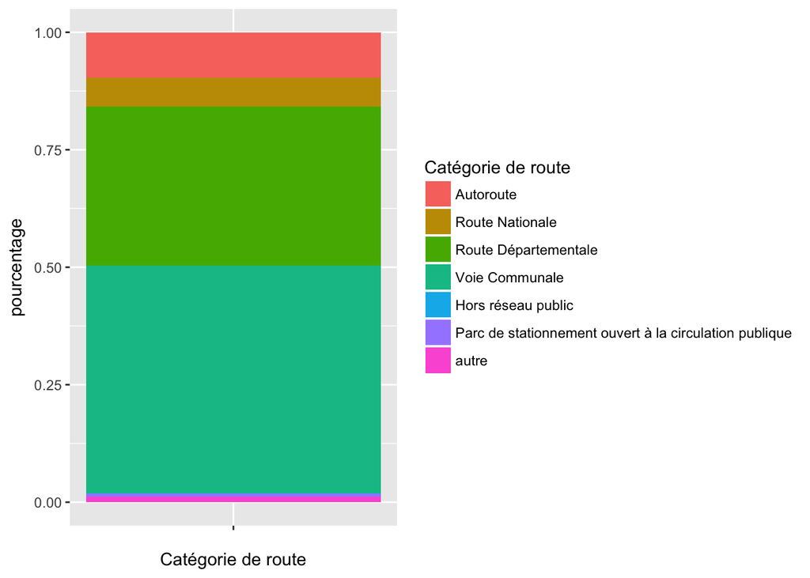

```r
ggplot(data_lieux_2016, aes(x=factor(0))) + geom_bar(aes(fill=catr), position ="fill") + scale_fill_discrete(name = "Catégorie de route", labels = c("Autoroute","Route Nationale","Route Départementale","Voie Communale","Hors réseau public","Parc de stationnement ouvert à la circulation publique","autre")) + labs(x = "Catégorie de route", y = "pourcentage") + scale_x_discrete(labels = c(""))
```

###### Anneau (beignet)

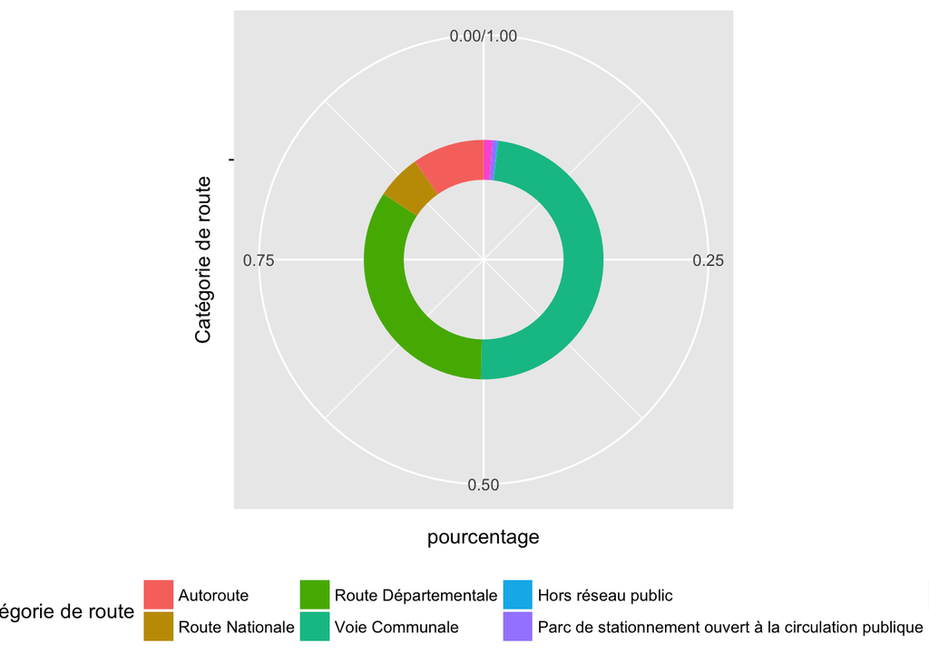

```r
ggplot(data_lieux_2016, aes(x=factor(0))) + geom_bar(aes(fill=catr), position ="fill", width = 0.2) + scale_fill_discrete(name = "Catégorie de route", labels = c("Autoroute","Route Nationale","Route Départementale","Voie Communale","Hors réseau public","Parc de stationnement ouvert à la circulation publique","autre")) + labs(x = "Catégorie de route", y = "pourcentage") + scale_x_discrete(labels = c("")) + theme(legend.position="bottom") + coord_polar(theta = "y")
```

###### Camembert

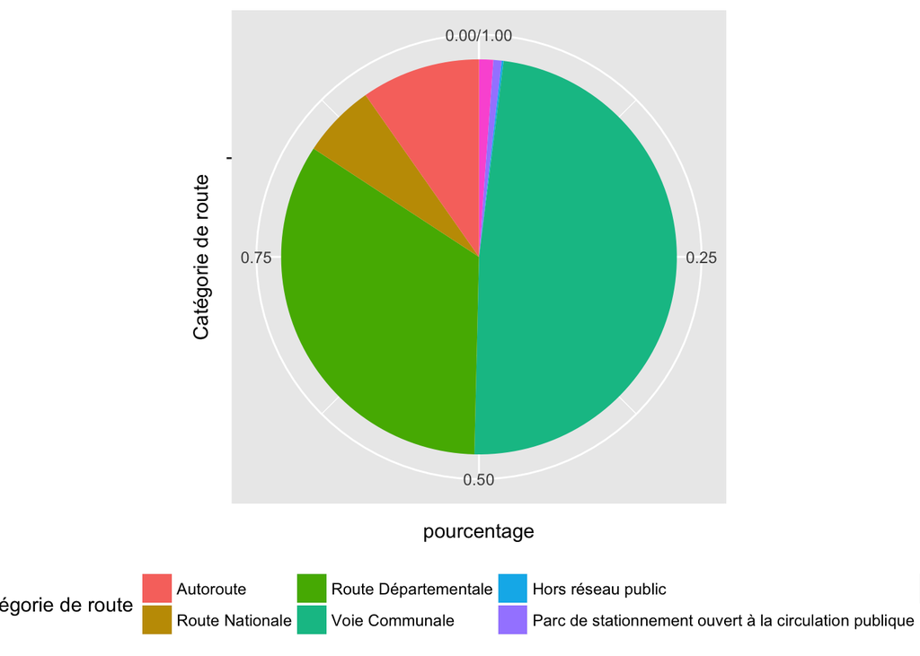

```r
ggplot(data_lieux_2016, aes(x=factor(0))) + geom_bar(aes(fill=catr), position ="fill", width = 1) + scale_fill_discrete(name = "Catégorie de route", labels = c("Autoroute","Route Nationale","Route Départementale","Voie Communale","Hors réseau public","Parc de stationnement ouvert à la circulation publique","autre")) + labs(x = "Catégorie de route", y = "pourcentage") + scale_x_discrete(labels = c("")) + theme(legend.position="bottom") + coord_polar(theta = "y")
```

##### Méthode 2 ###### Etape 1: Calcul le percentage de catégorie de route

```r
lieux_catr_2016_summary <- as.data.table(summary_lieux_2016[2:8,3:4])
is.data.table(lieux_catr_2016_summary)
```

```
## [1] TRUE
```

```r
lieux_catr_2016_summary$catr_Summary <- as.integer(as.character(lieux_catr_2016_summary$catr_Summary))
lieux_catr_2016_summary
```

```
##    <span style="color:red">catr</span>
## 1:                                   1
## 2:                                   2
## 3:                                   3
## 4:                                   4
## 5:                                   5
## 6:                                   6
## 7:                                   9
##    <span style="color:red">catr_Summary</span> catr_Summary
## 1:                                        5777           NA
## 2:                                        3590           NA
## 3:                                       20129           NA
## 4:                                       28752           NA
## 5:                                          91           NA
## 6:                                         401           NA
## 7:                                         692           NA
```

```r
lieux_catr_2016_summary <- lieux_catr_2016_summary[ , percentage := prop.table(`catr_Summary`)]
lieux_catr_2016_summary
lieux_catr_2016_summary$catr_names <- c("Autoroute","Route Nationale","Route Départementale","Voie Communale","Hors réseau public","Parc de stationnement ouvert à la circulation publique","autre")
```

###### Etape 2: Ordre de pourcentage

```r
lieux_catr_2016_summary$catr_names = factor(lieux_catr_2016_summary$catr_names, levels = lieux_catr_2016_summary$catr_names[order(lieux_catr_2016_summary$percentage)])
lieux_barplot <- ggplot(lieux_catr_2016_summary, aes(x="", y=percentage, fill=catr_names)) + geom_bar(width = 1, stat = "identity") + labs(x = "Catégorie de route", y = "pourcentage") + scale_fill_discrete(name = "Catégorie de route")
```

[output not shown]

```
## Warning: Removed 7 rows containing missing values (position_stack).
```

[figure not shown]

```r
lieux_pie <- lieux_barplot + coord_polar("y", start = 0)
lieux_pie + scale_fill_brewer(palette = "Blues") + theme_minimal() + scale_fill_discrete(name = "Catégorie de route")
```